# Background.

## Annual data with observed:

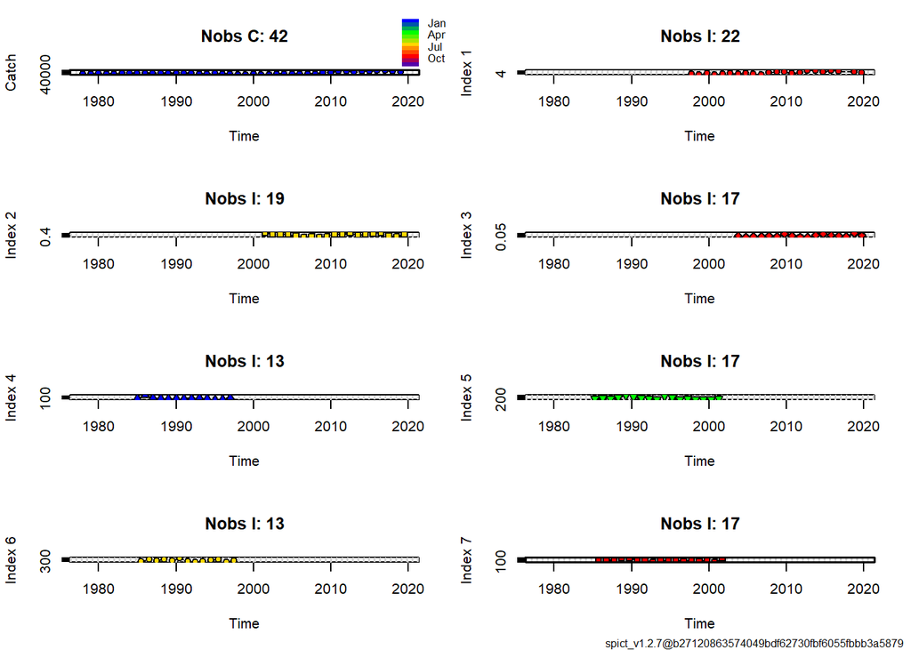

```r
year <- 1978:2019

resg1 <- subset(bioInd, FltSvy %in% 9)$value
resg2 <- subset(bioInd, FltSvy %in% 10)$value
resg3 <- subset(bioInd, FltSvy %in% 11)$value
resg4 <- subset(bioInd, FltSvy %in% 12)$value

timeresg1 <- 1985:1997
timeresg2 <- 1985:2001 + 0.25
timeresg3 <- 1985:1997 + 0.5
timeresg4 <- 1985:2001 + 0.75

dtc = 1
dteuler = 1/16

inp.hke <- list(obsC = catch.yr$tons, timeC = year, obsI = list(evhoe, porcupine,
    irigfs, resg1, resg2, resg3, resg4), timeI = list(timeevhoe, timeporcupine, timeirigfs,
    timeresg1, timeresg2, timeresg3, timeresg4), dtc = dtc, dteuler = dteuler)
inp.hke$phases$logbeta <- 1
inp.hke$phases$logalpha <- 1
inp.yr <- check.inp(inp.hke)
#' Plot the input data
plotspict.data(inp.yr, qlegend = TRUE)
```

Annual data with time lag

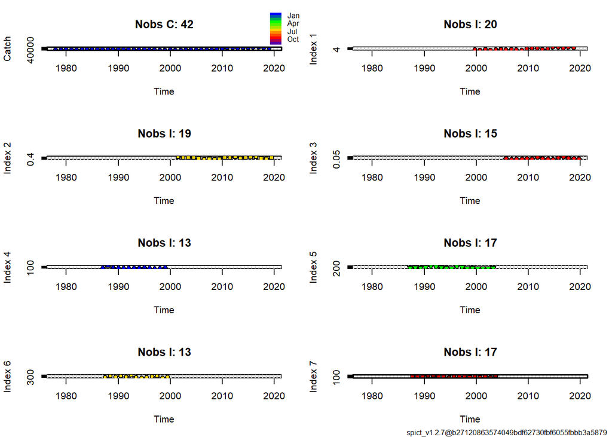

```r
year <- 1978:2019

resg1 <- subset(bioInd, FltSvy %in% 9)$value
resg2 <- subset(bioInd, FltSvy %in% 10)$value
resg3 <- subset(bioInd, FltSvy %in% 11)$value
resg4 <- subset(bioInd, FltSvy %in% 12)$value

timeresg1.lag <- 1985:1997 + 2
timeresg2.lag <- 1985:2001 + 0.25 + 2
timeresg3.lag <- 1985:1997 + 0.5 + 2
timeresg4.lag <- 1985:2001 + 0.75 + 2

evhoe.lag <- evhoe[1:(length(evhoe) - 2)]
irigfs.lag <- irigfs[1:(length(irigfs) - 2)]

timeevhoe.lag <- c(1999:2018) + 0.75
timeirigfs.lag <- 2005:2019 + 0.75

dtc = 1
dteuler = 1/16

inp.hke <- list(obsC = catch.yr$tons, timeC = year, obsI = list(evhoe.lag, porcupine,
    irigfs.lag, resg1, resg2, resg3, resg4), timeI = list(timeevhoe.lag, timeporcupine,
    timeirigfs.lag, timeresg1.lag, timeresg2.lag, timeresg3.lag, timeresg4.lag),
    dtc = dtc, dteuler = dteuler)
inp.hke$phases$logbeta <- 1
inp.hke$phases$logalpha <- 1
inp.yr.lag <- check.inp(inp.hke)
#' Plot the input data
plotspict.data(inp.yr.lag, qlegend = TRUE)
```

Annual data only with porcupine

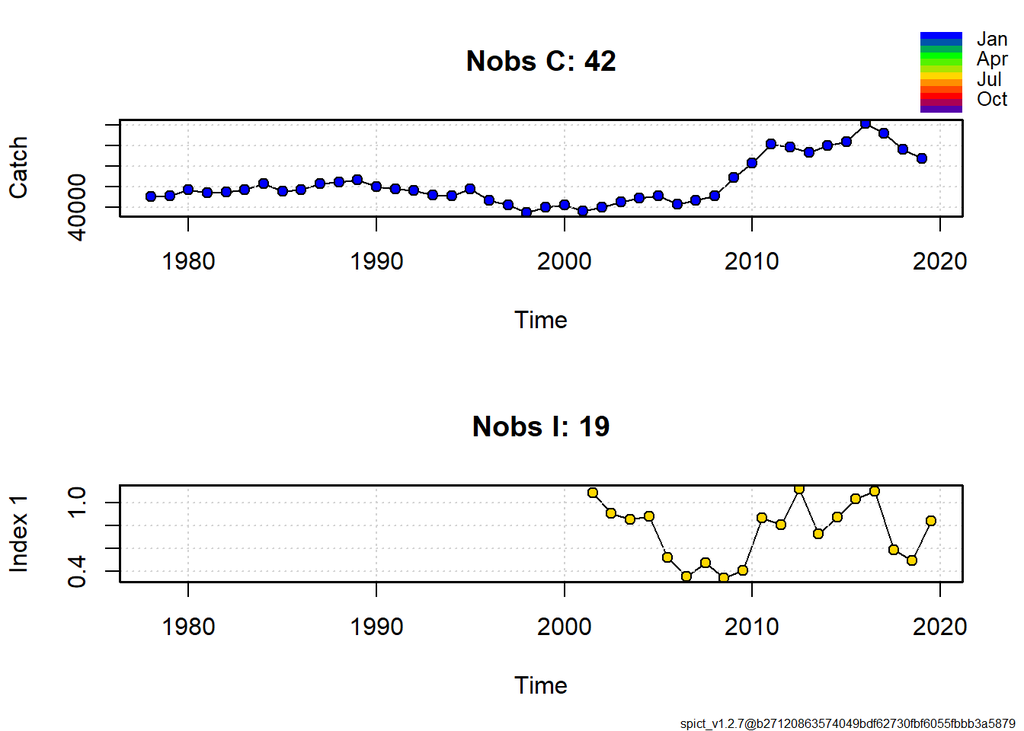

```r
dtc = 1
dteuler = 1/16

inp.hke <- list(obsC = catch.yr$tons, timeC = year, obsI = list(porcupine), timeI = list(timeporcupine),
    dtc = dtc, dteuler = dteuler)
inp.hke$phases$logbeta <- 1
inp.hke$phases$logalpha <- 1
inp.yr.porc <- check.inp(inp.hke)
#' Plot the input data
plotspict.data(inp.yr.porc, qlegend = TRUE)
```

# Model Fit

## Annual model

Fit the model to annual data with the default settings and analyse the results. The model converges in absolute terms but in relative convergence we get (4) ( I don’t know what it means)). The uncertainty obtained is huge and the values obtained for biomass, both absolute and relative, are not credible.

Things that need to be explored: + Add the two year time lag to the recruitment abudance indices (res.yr.lag). + Shorten the catch time series to 1987 (the first year with abundance index). + Tighter Schaefer prior for log n. + Shorthen the catch time series to 2001 and use only Porcupine index.

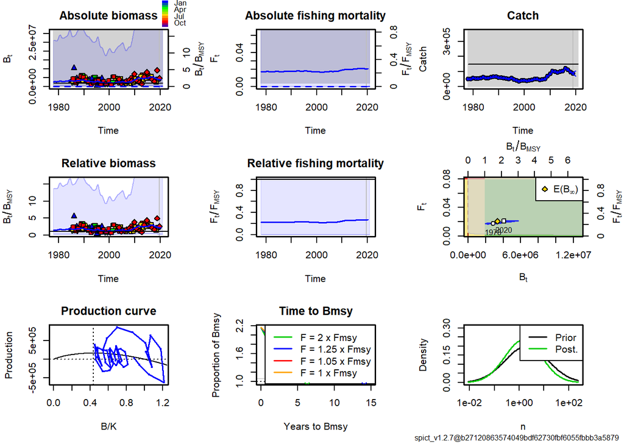

```r
res.yr <- fit.spict(inp.yr)


summary(res.yr)

resid.yr <- calc.osa.resid(res.yr)

plot(res.yr)
```

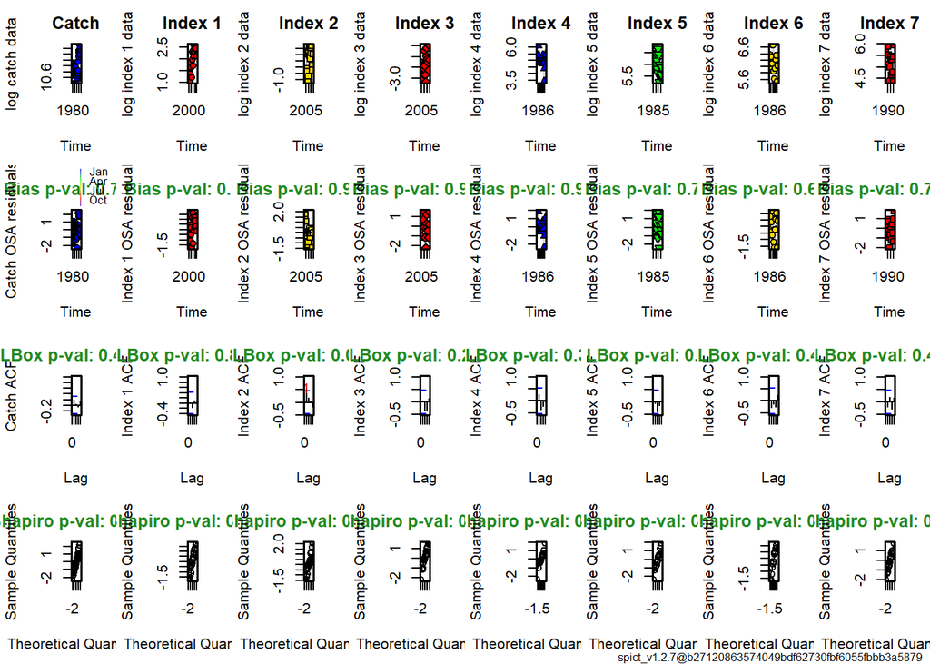

```r
# plotspict.osar(rep)


# Plot the residual diagnostics
plotspict.diagnostic(resid.yr)
```

## Annual model adding two year time lag.

The addition of the year lag does not solve the problem, the absolute numbers change but the broad picture is the same.

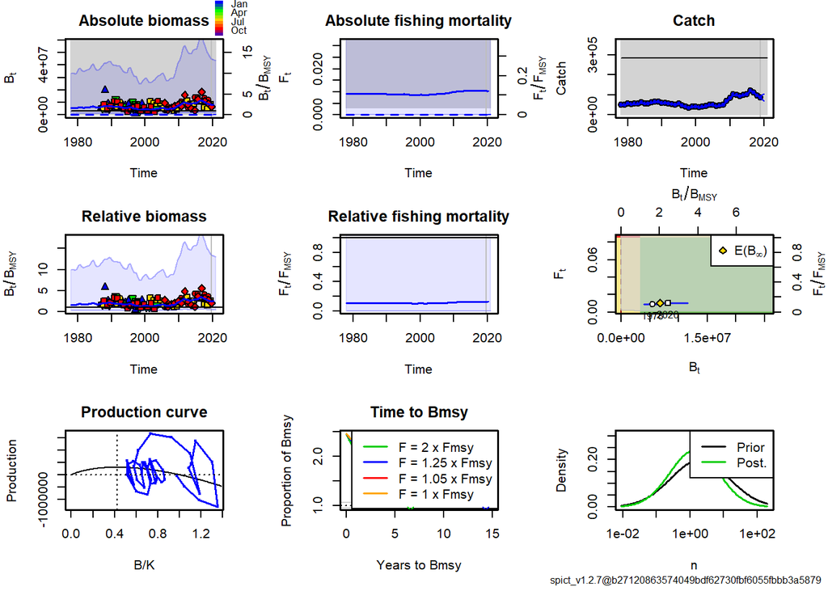

```r
res.yr.lag <- fit.spict(inp.yr.lag)

summary(res.yr.lag)

resid.yr.lag <- calc.osa.resid(res.yr.lag)

plot(res.yr.lag)
```

```r
# plotspict.osar(rep)
```

## Annual model adding two year time lag and shorter catch time series

Shortening the time series reduces slightly the uncertainty but still very high.

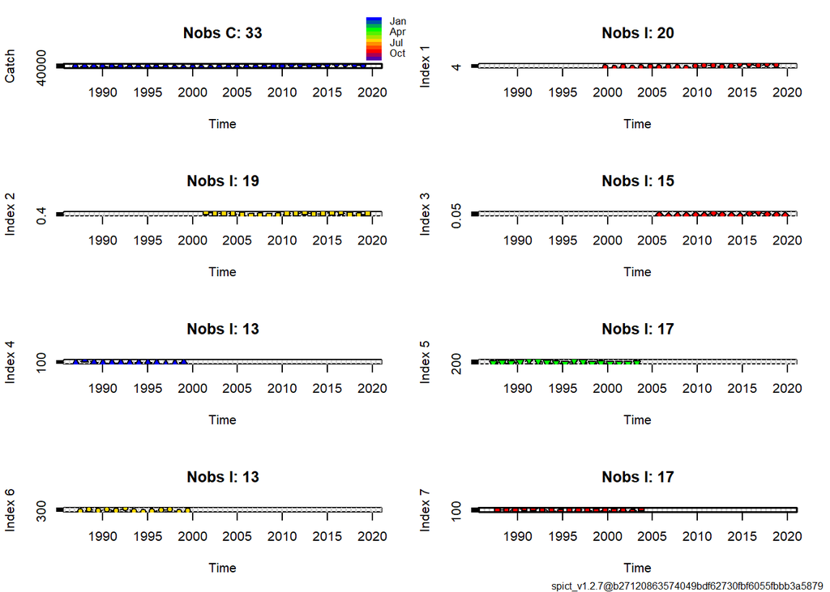

```r
dtc = 1
dteuler = 1/16

inp.hke <- list(obsC = catch.yr$tons[-(1:9)], timeC = 1987:2019, obsI = list(evhoe.lag,
    porcupine, irigfs.lag, resg1, resg2, resg3, resg4), timeI = list(timeevhoe.lag,
    timeporcupine, timeirigfs.lag, timeresg1.lag, timeresg2.lag, timeresg3.lag, timeresg4.lag),
    dtc = dtc, dteuler = dteuler)
inp.hke$phases$logbeta <- 1
inp.hke$phases$logalpha <- 1
inp.yr.lag.short <- check.inp(inp.hke)
#' Plot the input data
plotspict.data(inp.yr.lag.short, qlegend = TRUE)
```

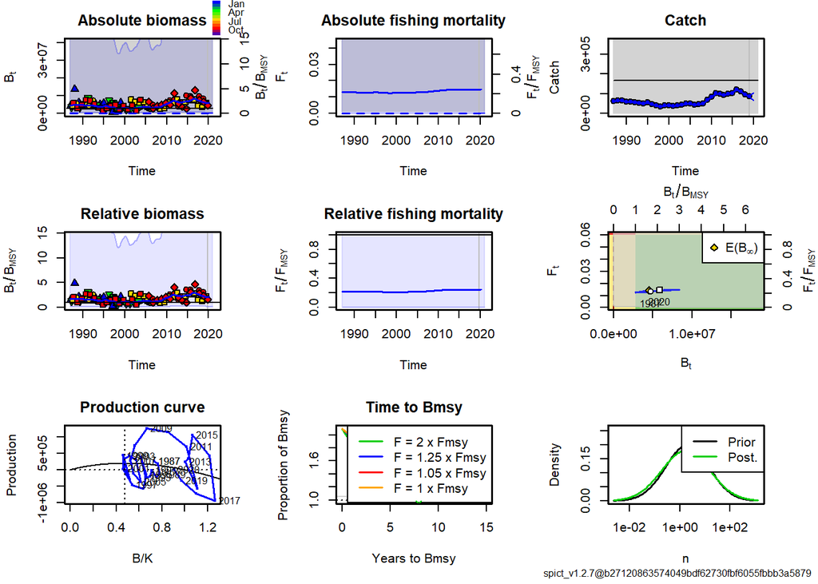

```r
res.yr.lag.short <- fit.spict(inp.yr.lag.short)

summary(res.yr.lag.short)

resid.yr.lag.short <- calc.osa.resid(res.yr.lag.short)

plot(res.yr.lag.short)
```

```r
# plotspict.osar(rep)
```

## Use only porcupine

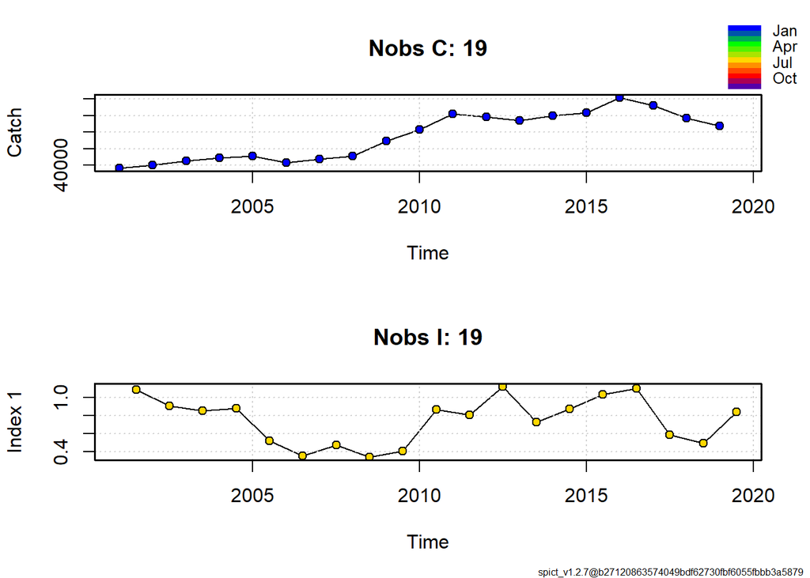

```r
# Add the two year time lag.


dtc = 1
dteuler = 1/16

inp.hke <- list(obsC = catch.yr$tons[-(1:23)], timeC = 2001:2019, obsI = list(porcupine),
    timeI = list(timeporcupine), dtc = dtc, dteuler = dteuler)
inp.hke$phases$logbeta <- 1
inp.hke$phases$logalpha <- 1
inp.porc <- check.inp(inp.hke)
#' Plot the input data
plotspict.data(inp.porc, qlegend = TRUE)
```

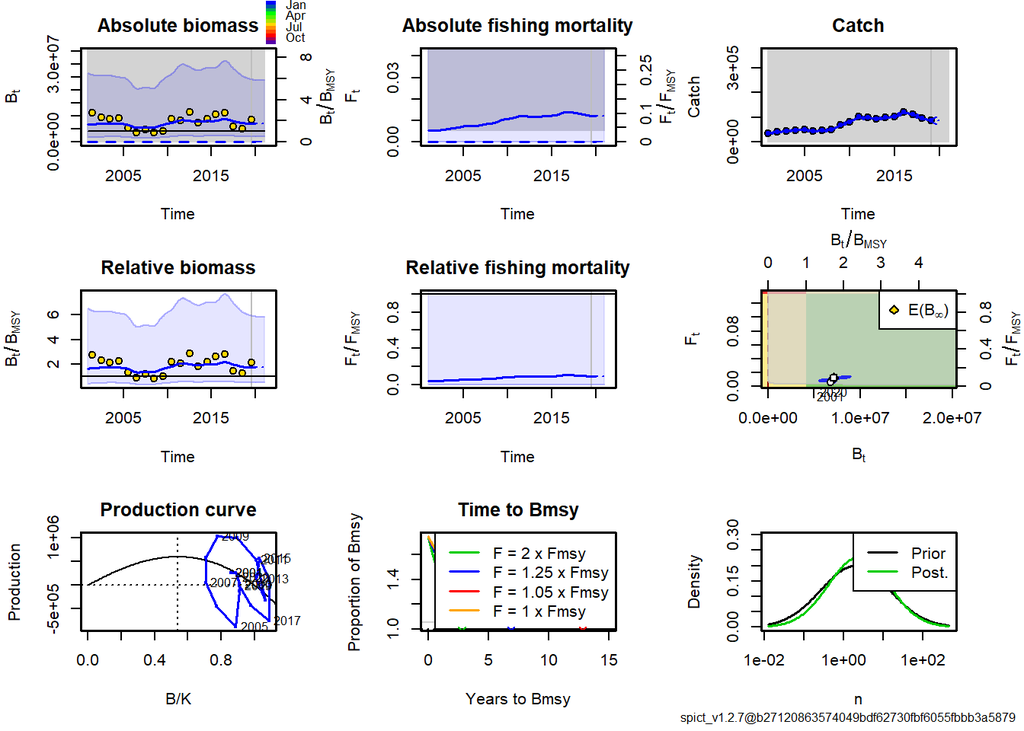

```r
res.porc <- fit.spict(inp.porc)

summary(res.porc)

resid.porc <- calc.osa.resid(res.porc)

plot(res.porc)
```

```r
# plotspict.osar(rep)
```